# Demo_Notebook slides

## Welcome to our Kick-Ass Demo

### Basic Implementation

```python
# Lets import what we need:

import numpy as np
import autograd  as ad
import autograd.variable as av
%matplotlib inline
```

Example 1: `f(x) = sin(x) + cos(x)` for x = 0

Define the mode you want to use : forward or reverse (default forward)

```python
# Let's try forward...
ad.set_mode('forward')
```

```python
# Set the x variable
x = av.Variable(0)
```

```python
# Perform first operation
# Pass the value through the sin block
b1 = ad.sin(x)
```

```python
# Perform the second operation
b2 = ad.cos(x)
```

```python
# Perform the final operation
b3 = b1 + b2
```

```python
# Return data
print(b3.data)
```

```
[1.]
```

```python
b3.compute_gradients()
```

```
array([[1.]])
```

```python
# Return gradient
print(b3.gradient)
```

```
[[1.]]
```

### Reverse Mode

The case of reverse mode is exactly similar, you just need to specify the mode at the beginning of the computation, before defining any variables

```python
# Let's try reverse...
ad.set_mode('reverse')

x = av.Variable(0)
b1 = ad.sin(x)
b2 = ad.cos(x)
b3 = b1 + b2

# Return data
print('data : ',b3.data)

# Important step, this is where the gradients are propagated backwards
b3.compute_gradients()

# Return gradient
print('gradient : ', b3.gradient)
```

```
data :  [1.]
gradient :  [[1.]]
```

If you want to use the reverse mode several times (for the optimizer for instance, you need to clear the computational graph everytime you want to do a new run of the function :

```python
ad.reset_graph()
b3.compute_gradients()

# Return gradient
print('gradient : ', b3.gradient)
```

```
gradient :  [[1.]]
```

If you don't do this, the gradients will accumulate in the graph, giving absurd results:

```python
b3.compute_gradients()
# Return gradient
print('gradient : ', b3.gradient)

b3.compute_gradients()
# Return gradient
print('gradient : ', b3.gradient)
```

```
gradient :  [[6.]]
gradient :  [[10.]]
```

### Optimization

Now let's create a function to compute the derivative across a range of values:

```python
# Return to forward mode
ad.set_mode('forward')
```

```python
def function(x):
    x1 = av.Variable(x)
    b1 = ad.sin(x1)
    b2 = ad.cos(x1)
    b3 = b1 + b2
    b3.compute_gradients()
    return(b3.data,b3.gradient)
```

```python
value = list()
data = list()
gradient = list()
for i in np.linspace(-2 * np.pi, 2 * np.pi):
    value.append(i)
    output = function(i)
    data.append(output[0])
    gradient.append(output[1][0])
```

Let's plot the values:

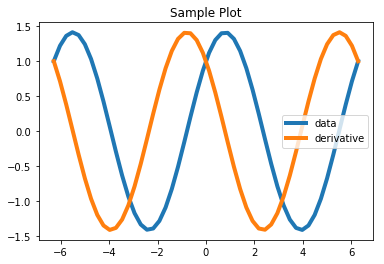

```python
import numpy as np
import matplotlib.pyplot as plt
import matplotlib as mpl

mpl.rc('lines', linewidth=4, color='g')
plt.plot(value,data,label='data')
plt.plot(value,gradient,label='derivative')
plt.title("Sample Plot")
plt.legend()
plt.show()
```

```python
def function(x):
    x1=av.Variable(x)
    # Elementary operations such as + - / *
    # Can be performed within other blocks
    b1 = ad.sin(x1 + 3)
    b2 = x1 / 2
    b3 = ad.cos(b2)
    b4 = b1/b3
    b5 = ad.exp(-x1)
    b7 = b4 + b5
    b7.compute_gradients()
    return(b7.data,b7.gradient)
```

```python
value = list()
data = list()
gradient = list()
for i in np.linspace(-2 * np.pi, 2 * np.pi):
    value.append(i)
    output = function(i)
    data.append(output[0][0])
    gradient.append(output[1][0])
```

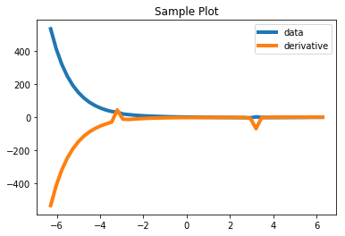

```python
plt.plot(value,data,label='data')
plt.plot(value,gradient,label='derivative')
plt.title("Sample Plot")
plt.legend()
plt.show()
```

Let's look at the ca ase of multiple inputs:

You need to specify that you are working with multiple inputs : when you define your input variables, you will use the special (class) method

```
x,y=Variable.multi_variables(data_for_x, data_for_y)
```

Example 3, using the vector framework with symetric role of x and y :

`f(x,y)=cos(0.5*(x+y)) * exp(-0.1*(x**2 + y**2))+0.1*(x+y) + exp(0.1*(3-(x+y))`

```python
def vector_function(x,y):
    x,y=av.Variable.multi_variables(x,y)


    b1 = ad.exp(-0.1*((x**2)+(y**2)))
    b2 = ad.cos(0.5*(x+y))
    b3 = b1*b2+0.1*(x+y)+ad.exp(0.1*(3-(x+y)))


    b3.compute_gradients()
    return(b3.data,b3.gradient)
```

```python
x,y=0.1,-0.1

data, gradient = vector_function(x,y)
```

In case of multiple inputs, the .gradient() method returns the gradients of the output node with respect to each of the inputs :

in our case, we defined z=f(x,y) we will have : \begin{equation*} z.gradients = [\frac{\partial z}{\partial x}, \frac{\partial z}{\partial y}] \end{equation*}

```python
gradient
```

```
[array([[-0.05494592]]), array([[-0.01502584]])]
```

Now if we want to perform Gradient Descent using our optimizer we can:

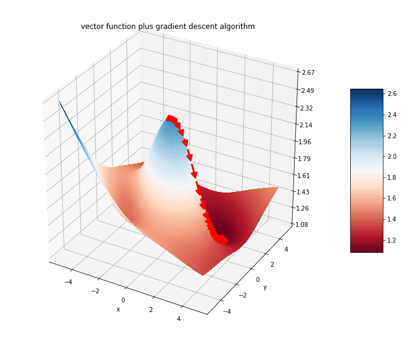

```python
# Plotting a nice surface and gradient descent

plot_nice_surface_and_gradients(vector_function, -5,5)
```

Example 3, using the vector framework with non-symetric role of x and y :

`f(x,y)=cos(x)*sin(y)`

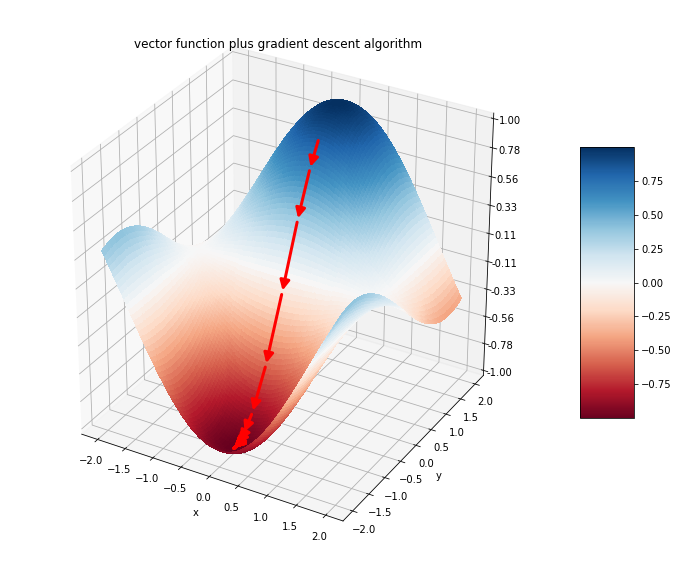

```python
plot_nice_surface_and_gradients(non_symetric, -2,2, startingPoint=(0,1))
```